# Validation

2025-07-08

# Setup

This relies on some bash magic that we used server side to rename the files before download, so that the name is e.g. OLD_Lib_LV123_collapsed.stat.gz, and symlinks the results to a folder which can then be downloaded using rsync.

```bash
#ssh dandycomp01fl
for line in $(find /projects/caeg/data/validation -name '*_collapsed.stat.gz' | grep 'v1.0.3' | grep 'results/metadmg/aggregate')
do
    status=""
    if echo "$line" | grep -q "eebd93d8414a08f40337174bb00ee3dc"; then # if this is in path, that means it's the new catalog
        status="test"
    fi
    if echo "$line" | grep -q "48ca4558f97def8149639ed5c1b40c37"; then # this is v1
        status="stable"
    fi
    basename=$(basename "$line")
    if [ ! -z $status ]; then
    ln -s "$line" "/home/dlm551/valfol2/${status}_$basename"
fi
done
```

We also need to download the metadata. Download from here https://docs.google.com/spreadsheets/d/16m6KTU2PfVh_40NzRZMKmTlEiArrnWHE4dMbYiGF4n8/edit?gid=0#gid=0 and save as metadata.csv

# Read in data

Start with libraries

```r
library(tidyverse)
library(data.table)
library(dtplyr)
library(rlang)
library(ggforce)
library(wesanderson)
library(viridis)
library(ggh4x)
library(vegan)
library(ggrepel)
library(purrr)
library(eulerr)
```

Get the metadata

```r
meta <- fread("metadata.csv")
```

We need all the aggregated stat files

```r
read_file <- function(f) {
  df <- fread(f, header=T, sep="\t", fill=T, nThread=2)
  df$sample_id <- f
  return(df)
}

file_list <- list.files(
  path = "aggregate/v1_v3",
  pattern = "\\.gz$",
  recursive = FALSE,
  full.names = TRUE
)

df <- do.call(rbind, lapply(file_list, read_file))
```

Now get library ID and comparison from the filename. This is the final df, we can do some funky plots with it

```r
df <- df %>%
  mutate(
    base = basename(sample_id),
    comparison = sapply(strsplit(base, "_"), `[`, 1),
    library_id  = sapply(strsplit(base, "_"), `[`, 3)
  ) %>%
  select(-base)
```

```r
df <- df %>% left_join(meta)
```

# Root plots

Get a df with just the root stats and make wide for easy plotting

```r
root <- df %>% filter(name == "root")
root_wide <- root %>%
  pivot_wider(
    id_cols = c(names(meta), c(library_id, taxid, name, rank, lca, taxa_path)),
    names_from = comparison,
    values_from = -c(names(meta), c(comparison,library_id, taxid, name, rank, lca, taxa_path))
  )
```

Number of reads assigned total

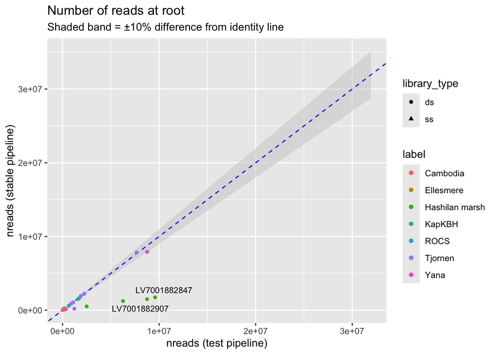

```r
p <- ggplot(root_wide, aes(x = nreads_test, y = nreads_stable)) +
  # 10% band around y = x
  geom_ribbon(aes(ymin = nreads_test * 0.9, ymax = nreads_test * 1.1),
              fill = "grey80", alpha = 0.5) +
  # y = x line
  geom_abline(color = "blue", linetype = "dashed") +
  # points
  geom_point(aes(color=label, shape=library_type)) +
  # labels for points outside ±10%
  geom_text_repel(
    data = root_wide %>% filter(abs(nreads_stable - nreads_test) > 0.1 * nreads_test),
    aes(label = library_id),
    size = 3
  ) +
  labs(
    x = "nreads (test pipeline)",
    y = "nreads (stable pipeline)",
    title = "Number of reads at root",
    subtitle = "Shaded band = ±10% difference from identity line"
  )
ggsave("plots/reads_root.pdf", plot=p)
print(p)
```

Average read length

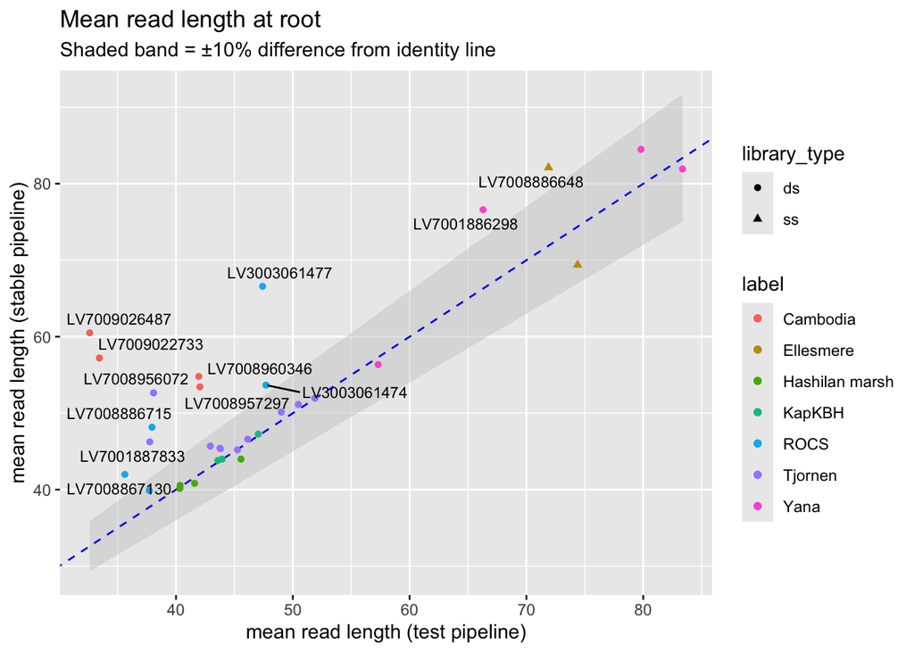

```r
p <- ggplot(root_wide, aes(x = mean_rlen_test, y = mean_rlen_stable)) +
  # 10% band around y = x
  geom_ribbon(aes(ymin = mean_rlen_test * 0.9, ymax = mean_rlen_test * 1.1),
              fill = "grey80", alpha = 0.5) +
  # y = x line
  geom_abline(color = "blue", linetype = "dashed") +
  # points
  geom_point(aes(color=label, shape=library_type)) +
  # labels for points outside ±10%
  geom_text_repel(
    data = root_wide %>% filter(abs(mean_rlen_stable - mean_rlen_test) > 0.1 * mean_rlen_test),
    aes(label = library_id),
    size = 3
  ) +
  labs(
    x = "mean read length (test pipeline)",
    y = "mean read length (stable pipeline)",
    title = "Mean read length at root",
    subtitle = "Shaded band = ±10% difference from identity line"
  )
ggsave("plots/rlen_root.pdf", plot=p)
print(p)
```

Average damage

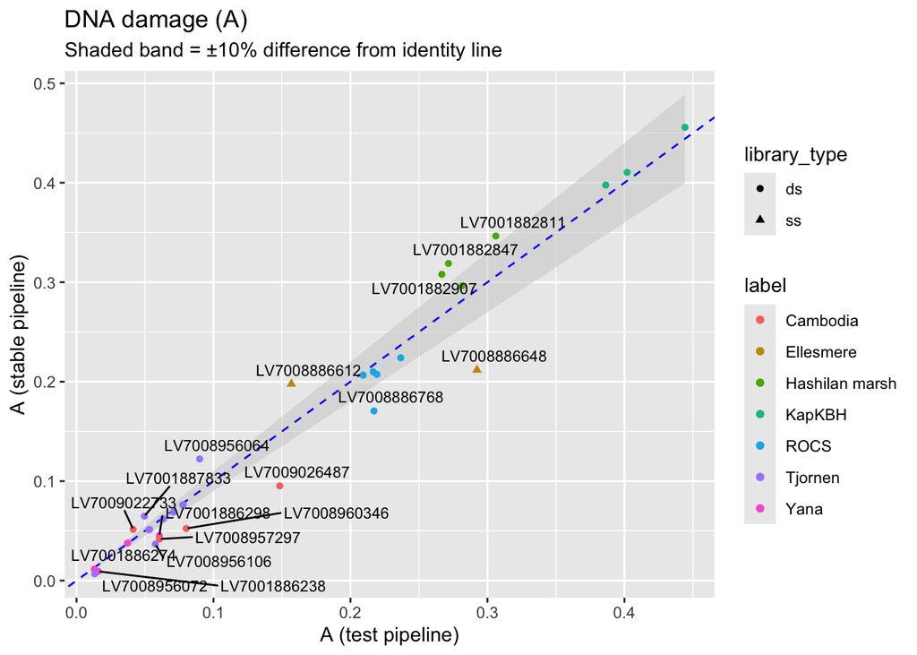

```r
p <- ggplot(root_wide, aes(x = A_test, y = A_stable)) +
  # 10% band around y = x
  geom_ribbon(aes(ymin = A_test * 0.9, ymax = A_test * 1.1),
              fill = "grey80", alpha = 0.5) +
  # y = x line
  geom_abline(color = "blue", linetype = "dashed") +
  # points
  geom_point(aes(color=label, shape=library_type)) +
  # labels for points outside ±10%
  geom_text_repel(
    data = root_wide %>% filter(abs(A_stable - A_test) > 0.1 * A_test),
    aes(label = library_id),
    size = 3
  ) +
  labs(
    x = "A (test pipeline)",
    y = "A (stable pipeline)",
    title = "DNA damage (A)",
    subtitle = "Shaded band = ±10% difference from identity line"
  )
ggsave("plots/dmg_root.pdf", plot=p)
print(p)
```

Superkingdom distribution

```r
s <- df %>% filter(rank == "phylum") %>%
    mutate(superkingdom = case_when(
      grepl('2759:"Eukaryota":', taxa_path) ~ "eukaryota",
      grepl('2:"Bacteria":', taxa_path) ~ "bacteria",
      grepl('10239:"Viruses":', taxa_path) ~ "virus",
      grepl('2157:"Archaea":', taxa_path) ~ "archaea")) %>%
  group_by(label, comparison, superkingdom) %>%
  summarise(total_nreads = sum(nreads))
```

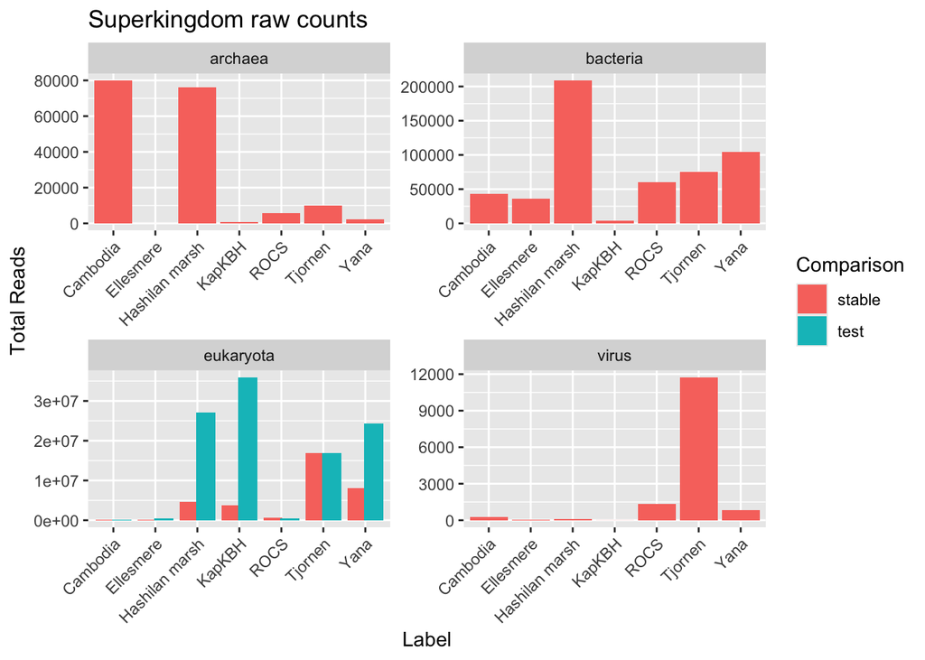

```r
p <- ggplot(s, aes(x = label, y = total_nreads, fill = comparison)) +
  geom_bar(stat = "identity", position = position_dodge(width = 0.8)) +
  facet_wrap(~superkingdom, scales="free") +
  labs(
    x = "Label",
    y = "Total Reads",
    fill = "Comparison",
    title = "Superkingdom raw counts"
  ) +
  theme(axis.text.x = element_text(angle = 45, hjust = 1))
ggsave("plots/superkingdom_nreads.pdf",plot=p)
print(p)
```

Now normalise to total nreads

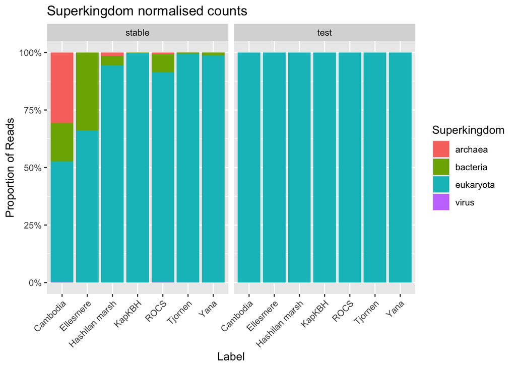

```r
df_prop <- s %>%
  group_by(label, comparison) %>%
  mutate(prop_reads = total_nreads / sum(total_nreads)) %>%
  ungroup()

p <- ggplot(df_prop, aes(x = label, y = prop_reads, fill = superkingdom)) +
  geom_bar(stat = "identity", position = "stack") +
  facet_wrap(~comparison) +
  labs(
    x = "Label",
    y = "Proportion of Reads",
    fill = "Superkingdom",
    title = "Superkingdom normalised counts"
  ) +
  scale_y_continuous(labels = scales::percent_format()) +
  theme(axis.text.x = element_text(angle = 45, hjust = 1))

ggsave("plots/superkingdom_proportion.pdf",plot=p)
print(p)
```

# Genus level eukaryotes

## Number of reads

Get just genus level, only eukaryotes and name the kingdoms

```r
genus <- df %>% filter(rank == "genus") |> # must be classified at genus level
    filter(grepl("Eukaryota", taxa_path)) |> # must be a Eukaryote
    mutate(PlantAnimal = case_when( # define plant/animal based on taxpath
      grepl("Viridiplantae", taxa_path) ~ "plant",
      grepl("Metazoa", taxa_path) ~ "animal",
      grepl("Fungi", taxa_path) ~ "fungi")) %>%
  filter(!is.na(PlantAnimal))
```

Do long to wide with genus df, here we remove taxa path because it is slightly different between the two taxonomy versions

```r
genus_wide <- genus %>% select(-taxa_path) %>%
  pivot_wider(
    names_from = comparison,
    values_from = -c(names(meta), c(comparison,library_id, taxid, name, rank, lca, PlantAnimal))
  )
```

Number of euk reads in old and new

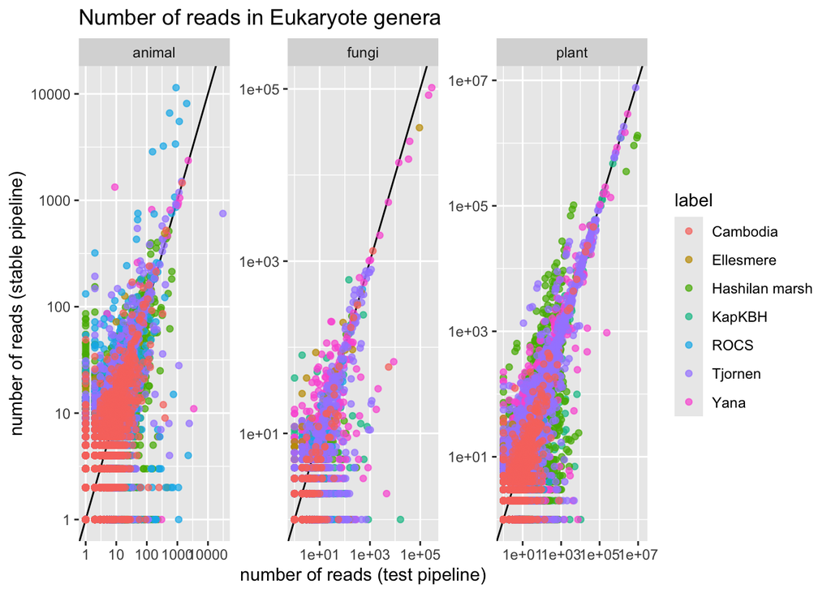

```r
p <- ggplot(genus_wide, aes(x = nreads_test, y = nreads_stable, color=label)) +
  geom_abline() +
  geom_point(alpha=0.7)+
  scale_y_continuous(trans="log10") +
  scale_x_continuous(trans="log10") +
  facet_wrap(~PlantAnimal, scales = "free") +
  labs(
    x = "number of reads (test pipeline)",
    y = "number of reads (stable pipeline)",
    title = "Number of reads in Eukaryote genera",
  )
ggsave("plots/reads_euk.pdf", plot=p)
print(p)
```

More faceted to see clearer

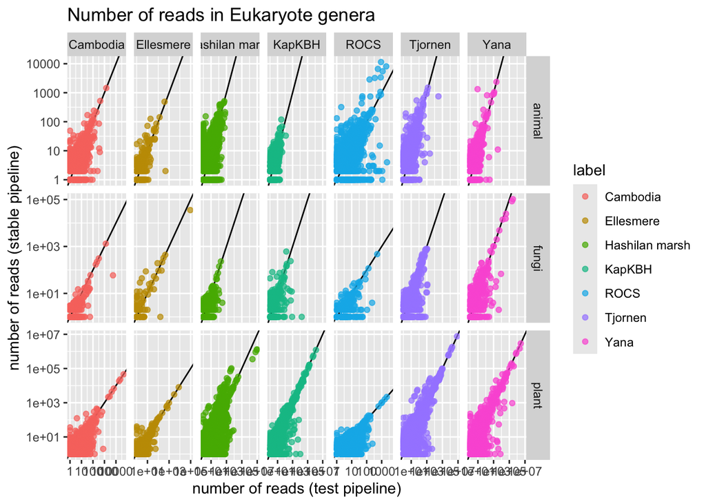

```r
p <- ggplot(genus_wide, aes(x = nreads_test, y = nreads_stable, color=label)) +
  geom_abline() +
  geom_point(alpha=0.7)+
  scale_y_continuous(trans="log10") +
  scale_x_continuous(trans="log10") +
  facet_grid2(vars(PlantAnimal),vars(label),scales="free") +
  labs(
    x = "number of reads (test pipeline)",
    y = "number of reads (stable pipeline)",
    title = "Number of reads in Eukaryote genera",
  )
ggsave("plots/reads_euk_facet.pdf", plot=p)
print(p)
```

## Volcano plot

Do volcano plot to show if taxa are differently enriched in test/stable * x-axis goes from (higher reads in stable - equal - higher reads in test) * y axis goes from (not significant - (0.05 threshold dashed line) - significant) * dashed vertical lines - 2 fold change

```r
summary_df <- genus %>%
  filter(comparison %in% c("test", "stable")) %>%
  group_by(label, PlantAnimal, taxid, name, comparison) %>%
  summarise(total_nreads = sum(nreads), .groups = "drop")

wide_df <- summary_df %>%
  filter(total_nreads >= 10) %>%
  pivot_wider(names_from = comparison, values_from = total_nreads)

# log2FC
wide_df <- wide_df %>%
  mutate(log2FC = log2((test + 1) / (stable + 1)))

# p-val per taxa per label
pvals <- genus %>%
  filter(comparison %in% c("test", "stable")) %>%
  group_by(label, PlantAnimal, taxid, name) %>%
  summarise(pval = tryCatch(
    wilcox.test(nreads ~ comparison)$p.value,
    error = function(e) NA_real_
  ), .groups = "drop")
```

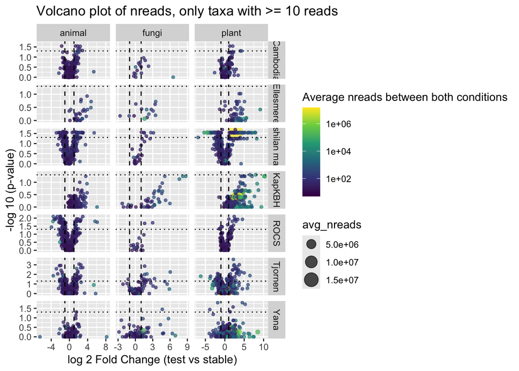

```r
# merge
volcano_df <- wide_df %>%
  left_join(pvals, by = c("label", "PlantAnimal", "taxid", "name")) %>%
  mutate(log10p = -log10(pval))

volcano_df$avg_nreads <- rowMeans(
  cbind(ifelse(is.na(volcano_df$test), 0, volcano_df$test),
        ifelse(is.na(volcano_df$stable), 0, volcano_df$stable))
)
p <- ggplot(volcano_df, aes(x = log2FC, y = log10p, color = avg_nreads, size = avg_nreads)) +
  geom_point(alpha = 0.7) +
  geom_vline(xintercept = c(-1, 1), linetype = "dashed") +
  geom_hline(yintercept = -log10(0.05), linetype = "dotted") +
  labs(
    x = "log 2 Fold Change (test vs stable)",
    y = "-log 10 (p-value)",
    title = "Volcano plot of nreads, only taxa with >= 10 reads",
    color = "Average nreads between both conditions"
  ) +
  scale_colour_viridis_c(trans="log10") +

  facet_grid2(vars(label),vars(PlantAnimal),scales="free")

ggsave("plots/reads_euk_volcano.pdf", plot=p)
print(p)
```

Now find the outliers

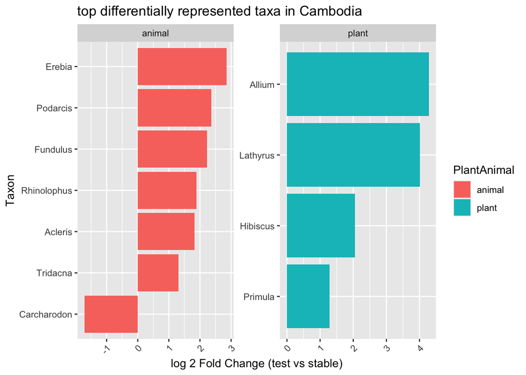

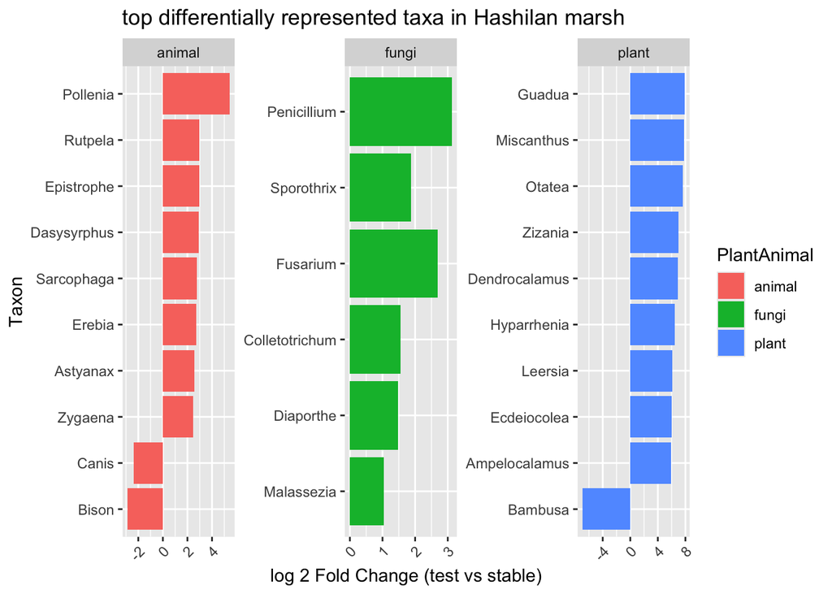

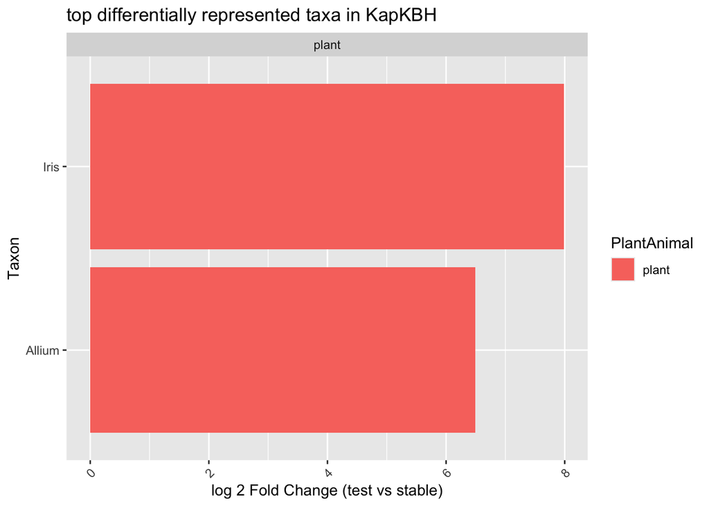

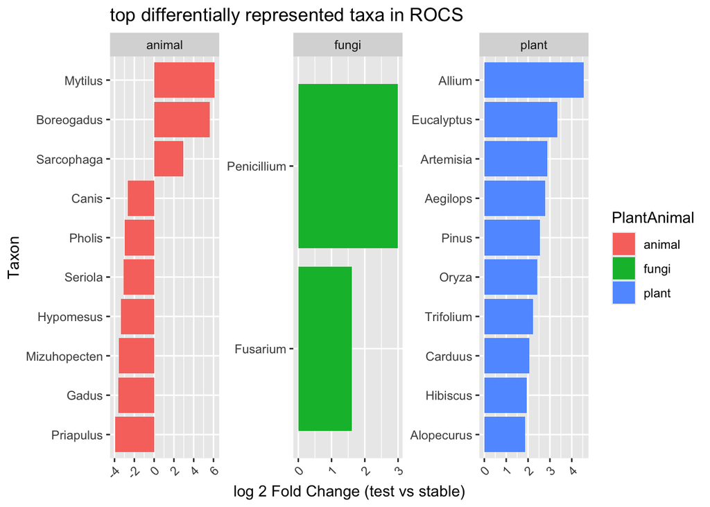

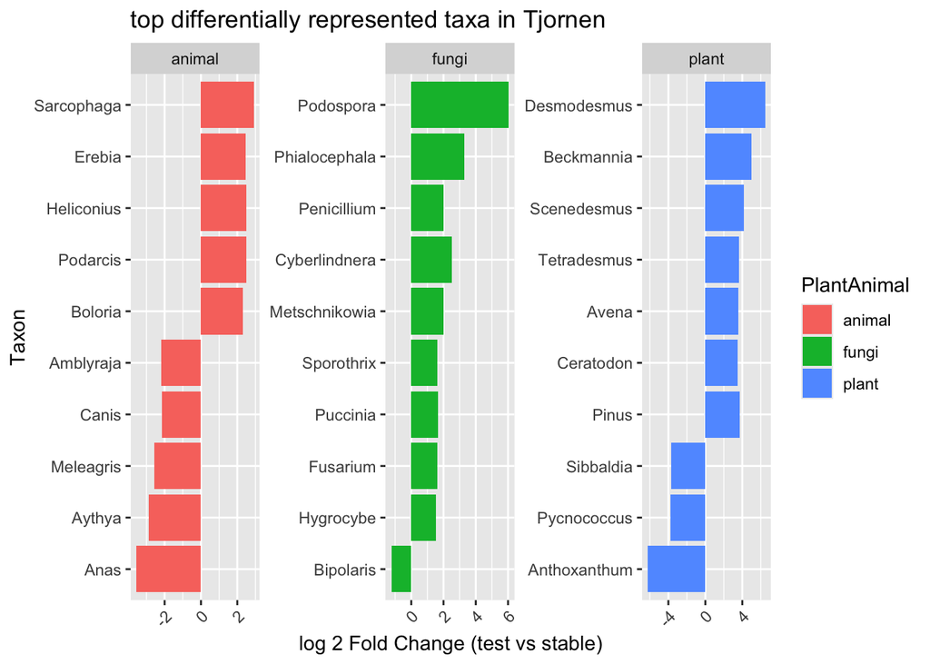

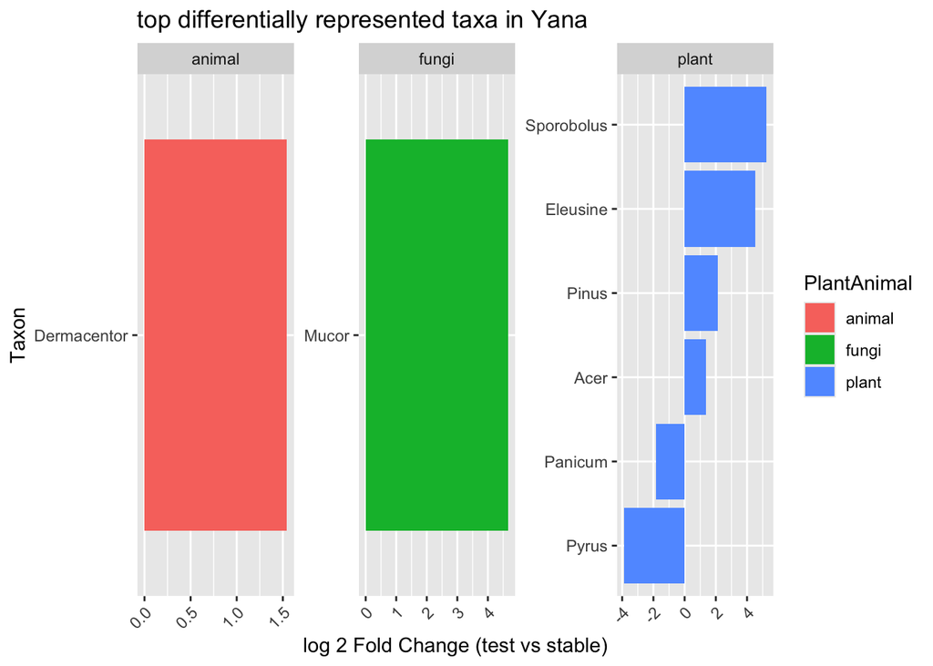

```r
top_hits <- volcano_df %>%
  filter(!is.na(log2FC), !is.na(pval)) %>%
  filter(pval < 0.05) %>% # get significiant
  group_by(label, PlantAnimal) %>%
  slice_max(order_by = abs(log2FC), n = 10, with_ties = FALSE) %>% # keep top 10 taxa per group
  ungroup() %>%
  mutate(
    name = fct_reorder(name, log2FC)
  )

for (lab in unique(top_hits$label)) {
  p <- ggplot(top_hits %>% filter(label == lab), aes(x = name, y = log2FC, fill = PlantAnimal)) +
  geom_col() +
  facet_wrap(~PlantAnimal, scales = "free") +
  coord_flip() +
  labs(
    title = paste0("top differentially represented taxa in ", lab),
    x = "Taxon",
    y = "log 2 Fold Change (test vs stable)"
  ) +
  theme(
    axis.text.x = element_text(angle = 45, hjust = 1),
    strip.text.y = element_text(angle = 0)
  )
  ggsave(paste0("plots/reads_euk_volcano_diff_", lab, ".pdf"), plot=p)
  print(p)
}
```

## Taxa gain/loss

```r
read_diff <- genus %>%
  select(name,taxid, library_id, comparison, nreads, PlantAnimal,label) %>%
  pivot_wider(names_from = comparison, values_from = nreads) %>%
  mutate(read_change = test - stable)
```

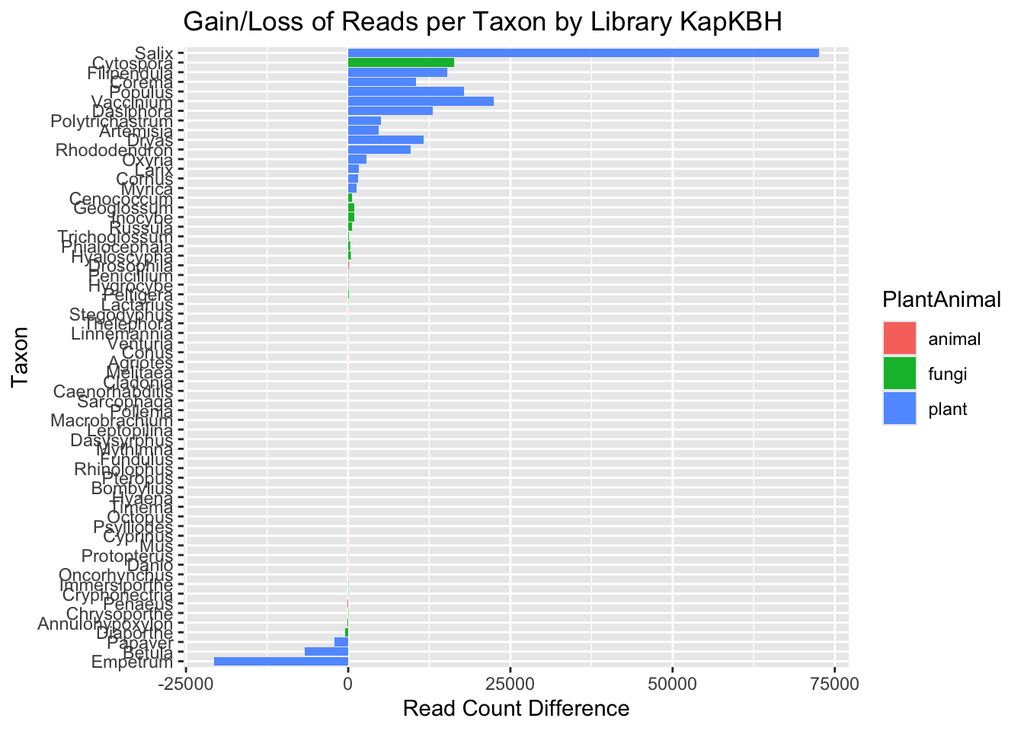

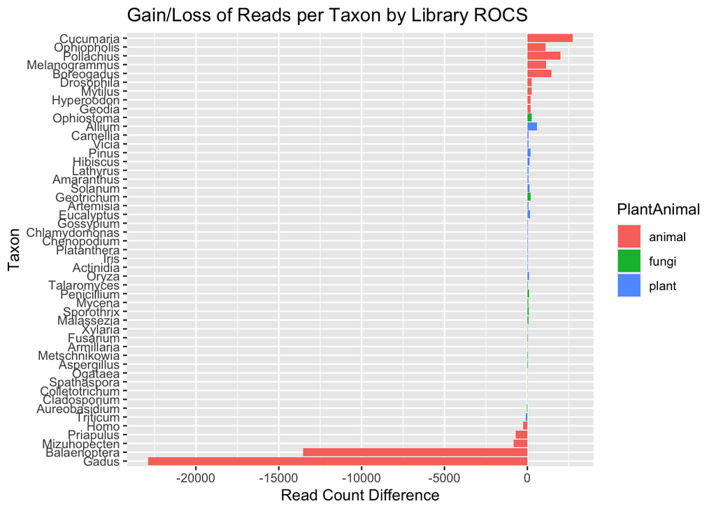

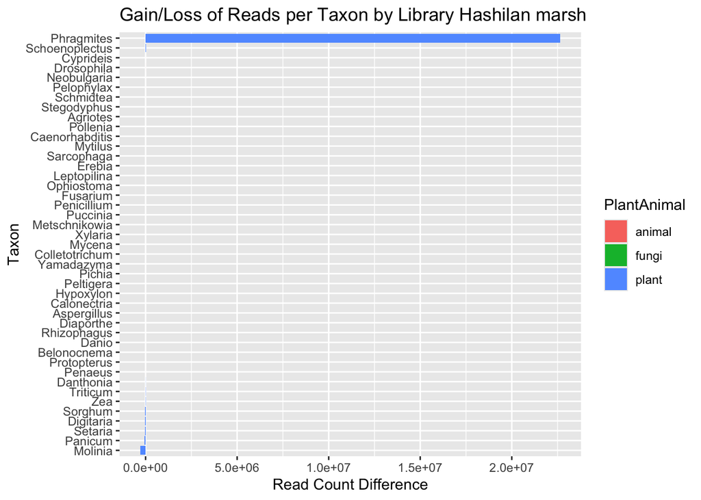

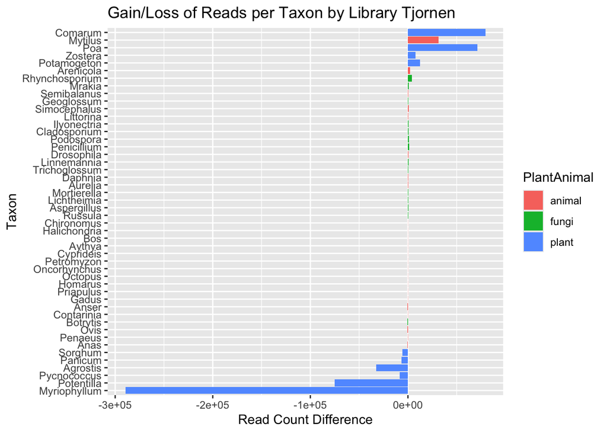

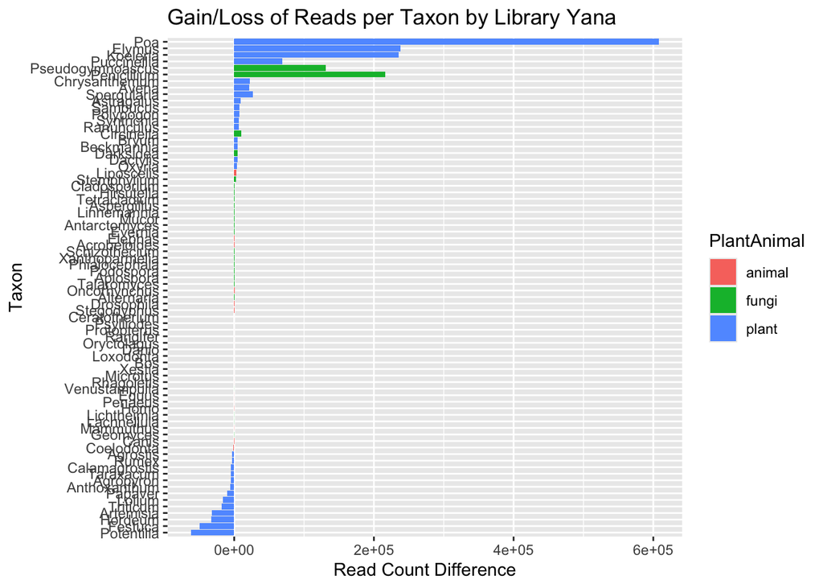

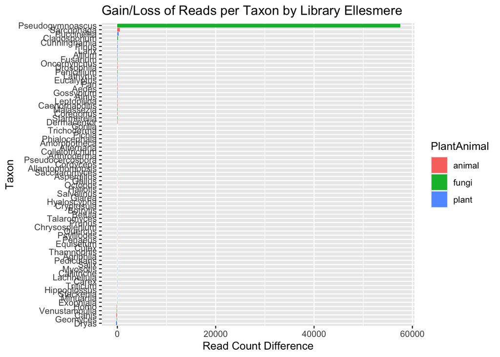

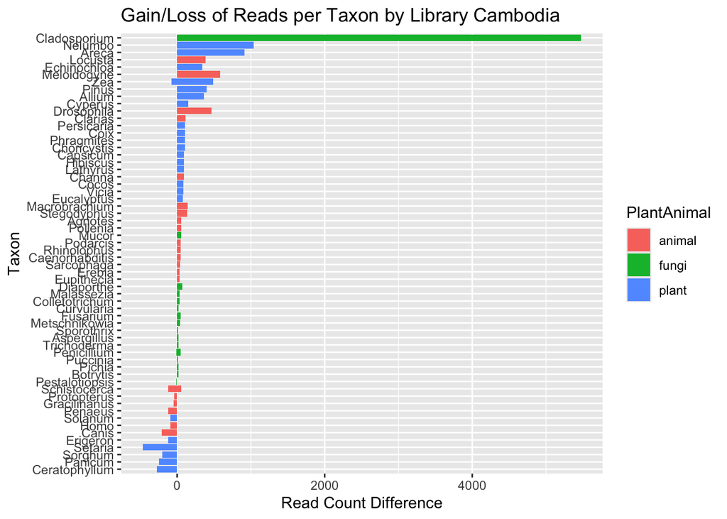

```r
for (l in unique(df$label)) {

  d <- read_diff %>%
    filter(label == l) %>%
    group_by(PlantAnimal) %>%
    arrange(desc(abs(read_change))) %>%
    slice_head(n = 30)  # top 20 changes

 p <- ggplot(d, aes(x = reorder(name, read_change), y = read_change, fill = PlantAnimal)) +
  geom_col() +
  coord_flip() +
  labs(
    x = "Taxon",
    y = "Read Count Difference",
    title = paste0("Gain/Loss of Reads per Taxon by Library ", l)
  )

 t = paste0("plots/taxa_gainloss_",l,".pdf")
 ggsave(t, plot=p)
 print(p)
}
```

## Damage plots

### Big pdf

We make a giant pdf file called damage_patterns.pdf for the comparisons

```r
plot_pipeline_comparison <- function(df2, only5 = FALSE) {

  # Get info
  nreads_old <- df2 %>% filter(comparison == "stable") %>% pull(nreads)
  nreads_new <- df2 %>% filter(comparison == "test") %>% pull(nreads)
  A_b_old <- df2 %>% filter(comparison == "stable") %>% pull(A)
  A_b_new <- df2 %>% filter(comparison == "test") %>% pull(A)
  lib_id <- df2$library_id[1]
  label <- df2$label[1]
  taxon <- df2$name[1]
  taxid <- df2$taxid[1]

  x_cols <- grep("^fwdx\\d+$", names(df2), value = TRUE)
  f_cols <- grep("^fwf\\d+$", names(df2), value = TRUE)

  long_df <- bind_rows(
    df2 %>%
      filter(comparison == "stable") %>%
      select(all_of(x_cols), all_of(f_cols)) %>%
      pivot_longer(everything(), names_to = "metric", values_to = "value") %>%
      mutate(position = as.integer(str_extract(metric, "\\d+")),
             type = ifelse(str_starts(metric, "fwdx"), "x", "f"),
             comparison = "stable"),
    df2 %>%
      filter(comparison == "test") %>%
      select(all_of(x_cols), all_of(f_cols)) %>%
      pivot_longer(everything(), names_to = "metric", values_to = "value") %>%
      mutate(position = as.integer(str_extract(metric, "\\d+")),
             type = ifelse(str_starts(metric, "fwdx"), "x", "f"),
             comparison = "test")
  ) %>%
    filter(!is.na(value)) %>%
    mutate(type = factor(type, levels = c("f", "x")))

  if (only5) {
    long_df <- long_df %>% filter(position < 7)
  }

  A_points <- tibble(
    position = 0,
    value = c(A_b_old, A_b_new),
    type = "A",
    comparison = c("old", "new")
  )

  title <- paste0(
    taxon, " (taxid: ", taxid, ")\n",
    "Library: ", lib_id, ", Label: ", label, "\n",
    "nreads (stable/test): ", nreads_old, " / ", nreads_new,
    ", A: ", round(A_b_old, 3), " / ", round(A_b_new, 3)
  )

  ggplot(long_df, aes(x = position, y = value, color = comparison, linetype = type)) +
    geom_line() +
    geom_point(data = filter(long_df, type == "f")) +
    geom_point(data = A_points, aes(shape = type), size = 3, stroke = 1.2, inherit.aes = TRUE) +
    scale_color_manual(values = c("stable" = "royalblue4", "test" = "tomato4")) +
    scale_linetype_manual(values = c("x" = "solid", "f" = "dashed")) +
    scale_shape_manual(values = c(A = 8)) +
    labs(
      title = title,
      x = "Position from 5' end",
      y = "Damage Estimate",
      color = "comparison",
      linetype = "Metric",
      shape = NULL
    )
}
```

```r
# get taxa with >= 100 reads
valid_taxa <- genus %>%
  group_by(name, taxid, library_id) %>%
  summarise(
    n_old = nreads[comparison == "stable"],
    n_new = nreads[comparison == "test"],
    .groups = "drop"
  ) %>%
  filter(n_old >= 100, n_new >= 100)
```

```r
genus_filtered <- semi_join(genus, valid_taxa, by = c("name", "taxid", "library_id"))

# split into groups
groups <- genus_filtered %>%
  group_by(name, taxid, library_id) %>%
  group_split()

# save plots
plots <- list()
for (df2 in groups) {
  p <- plot_pipeline_comparison(df2)
    plots <- append(plots, list(p))
}

# Save only if we have valid plots
if (length(plots) > 0) {
  pdf("damage_patterns.pdf", width = 8, height = 6)
  for (p in plots) {
    print(p)
  }
  dev.off()
} else {
  message("No valid plots generated — PDF not created.")
}
```

### Just damage estimates

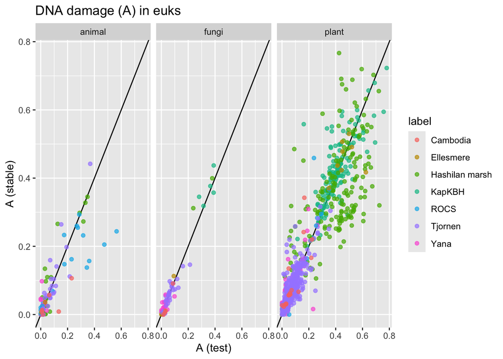

```r
p <- genus_wide %>% filter(nreads_test >= 100 & nreads_stable >= 100) %>%
ggplot(aes(x=A_test, y = A_stable, color = label)) +
  geom_abline() +
  geom_point(alpha = 0.7) +
  facet_wrap(~PlantAnimal) +
  labs(
    x = "A (test)",
    y = "A (stable)",
    title = "DNA damage (A) in euks"
  )
ggsave("plots/dmg_euk.pdf", plot=p)
print(p)
```

## Number of reads total for plant and animal

```r
id_df <- genus %>% group_by(library_id, label, PlantAnimal,comparison) %>%
  summarise(total_nreads = sum(nreads)) %>%
  pivot_wider(names_from = comparison, values_from = total_nreads)
```

```
## can override using the `.groups` argument.
```

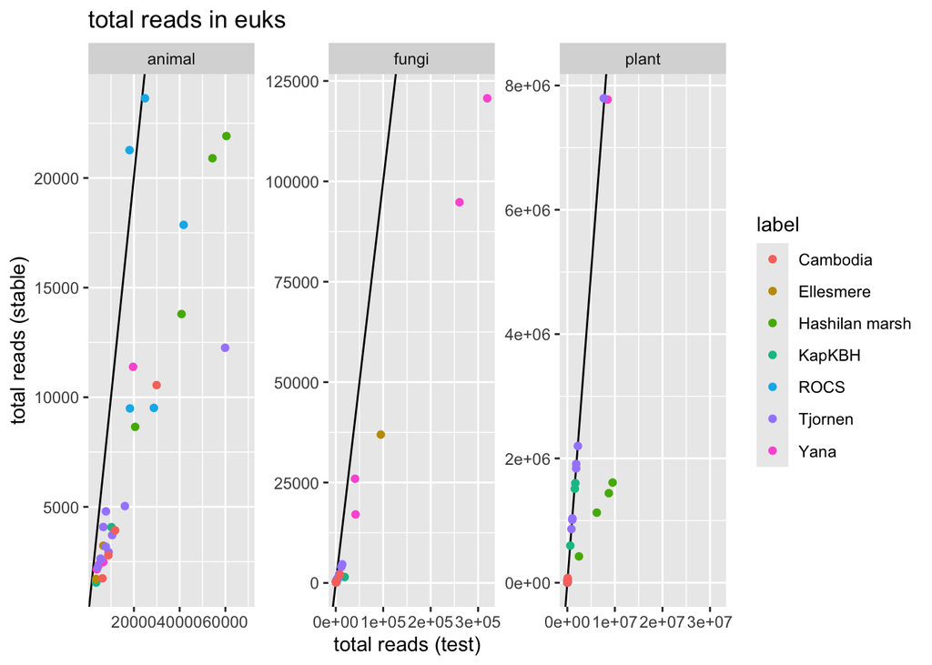

```r
p <- ggplot(id_df, aes(x=test, y =stable, color=label)) +
  geom_abline() +
  geom_point() +
  facet_wrap(~PlantAnimal, scales="free")+
  labs(
    x = "total reads (test)",
    y = "total reads (stable)",
    title = "total reads in euks"
  )
ggsave("plots/reads_total_euk.pdf", plot=p)
print(p)
```

# Number of taxa identified

```r
id_df <- genus %>% group_by(library_id, label, PlantAnimal,comparison) %>%
  summarise(num = n()) %>%
  pivot_wider(names_from = comparison, values_from = num)
```

```
## can override using the `.groups` argument.
```

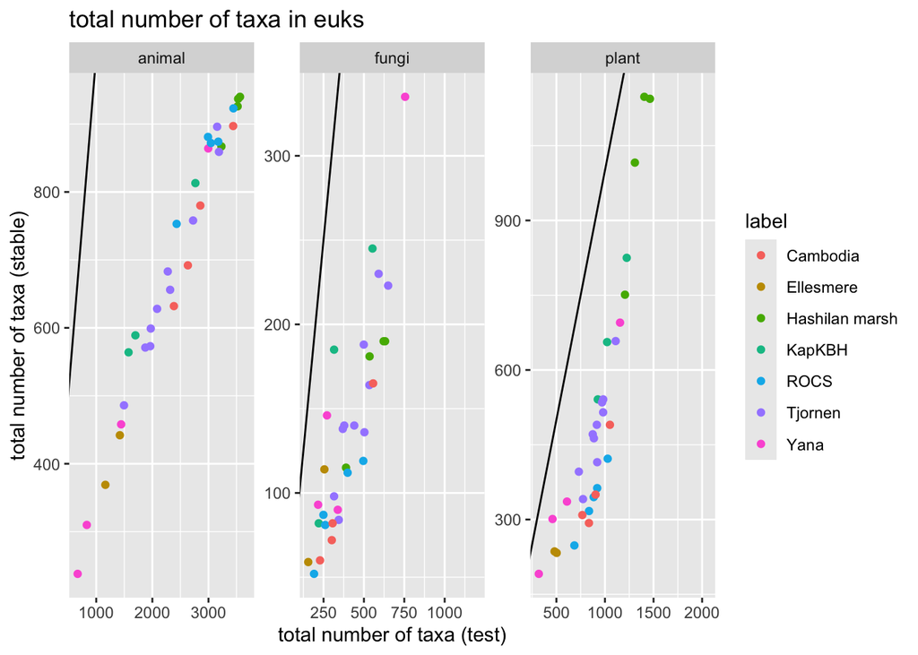

```r
p <- ggplot(id_df, aes(x=test, y =stable, color=label)) +
  geom_abline() +
  geom_point() +
  facet_wrap(~PlantAnimal, scales="free") +
  labs(
    x = "total number of taxa (test)",
    y = "total number of taxa (stable)",
    title = "total number of taxa in euks"
  )
ggsave("plots/taxa_euk.pdf", plot=p)
print(p)
```

# Taxa

Which taxa are unique? Do Venn diagram

```r
library_ids <- unique(genus$library_id)
plots <- list()

for (lib in library_ids) {
  df_lib <- genus %>%
    filter(library_id == lib & nreads >= 100)

  label <- unique(df_lib$label)

  # Loop over PlantAnimal categories
  venn_plots <- list()
  for (group in unique(df_lib$PlantAnimal)) {
    df_group <- df_lib %>%
      filter(PlantAnimal == group)

    taxa_old <- df_group %>%
      filter(comparison == "stable") %>%
      pull(name) %>%
      unique()

    taxa_new <- df_group %>%
      filter(comparison == "test") %>%
      pull(name) %>%
      unique()

    venn_counts <- list(
      old = taxa_old,
      new = taxa_new
    )

    fit <- tryCatch(euler(venn_counts), error = function(e) NULL)

    if (!is.null(fit)) {
      p <- plot(
        fit,
        fills = list(fill = c("royalblue4", "tomato4"), alpha = 0.5),
        quantities = TRUE,
        main = paste("Library:", lib, "|", group)
      )
      venn_plots <- append(venn_plots, list(p))
    }
  }

  if (length(venn_plots) > 0) {
    combined <- do.call(gridExtra::arrangeGrob, c(venn_plots, ncol = 2,
      top = paste("Taxa (>=10 reads) overlap for library:", lib, "-", label)))
    plots <- append(plots, list(combined))
  }
}

# Save to PDF
if (length(plots) > 0) {
  pdf("venn_taxa_by_library.pdf", width = 10, height = 8)
  for (p in plots) {
    grid::grid.draw(p)
    grid::grid.newpage()
  }
  dev.off()
} else {
  message("No valid plots generated — PDF not created.")
}
```

# PCoA

## Regular

Do PCoA, three plots per label (plants, animals, fungi), each dot is one library, lines go between the dots, length of line is how dissimilar they are

```r
plots <- list()

for (lab in unique(genus$label)) {

  for (group in c("plant", "animal", "fungi")) {

    genus_sub <- genus %>%
      filter(label == lab, PlantAnimal == group, !is.na(name), !is.na(nreads)) %>%
      mutate(
        taxa = paste0(name, "-", taxid),
        sample = paste(library_id, comparison, sep = "_")
      )

    # Skip if too few samples
    if (length(unique(genus_sub$sample)) < 3) next

    # Pivot to wide
    tmp_dt <- as.data.table(genus_sub)
    wide_counts <- dcast(tmp_dt, taxa ~ sample, value.var = "nreads", fill = 0)

    if (nrow(wide_counts) < 2) next

    rownames(wide_counts) <- wide_counts$taxa
    wide_data <- as.data.frame(wide_counts[, -1])

    # Compute distances and PCoA
    dist_matrix <- vegdist(t(wide_data), method = "bray")
    pcoa_result <- cmdscale(dist_matrix, k = 2, eig = TRUE)

    pcoa_df <- data.frame(pcoa_result$points)
    colnames(pcoa_df) <- c("PCoA1", "PCoA2")
    pcoa_df$sample <- rownames(pcoa_result$points)

    # Join metadata
    pcoa_df <- pcoa_df %>%
      separate(sample, into = c("library_id", "comparison"), sep = "_", remove = FALSE) %>%
      left_join(
        genus_sub %>%
          select(library_id, comparison) %>%
          distinct(),
        by = c("library_id", "comparison")
      )

    # Plot
    p <- ggplot(pcoa_df, aes(x = PCoA1, y = PCoA2, color = comparison)) +
      geom_path(aes(group = library_id), color = "grey50", linewidth = 0.5, alpha = 0.7) +
      geom_point(size = 4) +
      labs(
        title = paste("PCoA | Label:", lab, "| Group:", group),
        x = "PCoA1",
        y = "PCoA2",
        color = "Pipeline"
      ) +
      theme_test(base_size = 15)

    plots <- append(plots, list(p))
  }
}

# Save all to PDF
if (length(plots) > 0) {
  pdf("pcoa.pdf", width = 10, height = 8)
  for (p in plots) print(p)
  dev.off()
} else {
  message("No valid PCoA plots generated.")
}
```

## Exclusion

Can we do a thing where we remove taxa one by one, and measure if the points become nearer? That would find the taxa that drive the difference between runs

```r
plots <- list()

for (lab in unique(genus$label)) {

  for (group in c("plant", "animal", "fungi")) {

    df2 <- genus %>%
      filter(label == lab, PlantAnimal == group, !is.na(name), !is.na(nreads)) %>%
      mutate(
        taxa = paste0(name, "-", taxid),
        sample = paste(library_id, comparison, sep = "_")
      )

    # Pivot full matrix
    tmp_dt <- as.data.table(df2)
    wide_counts <- dcast(tmp_dt, taxa ~ sample, value.var = "nreads", fill = 0)
    rownames(wide_counts) <- wide_counts$taxa
    wide_data <- as.data.frame(wide_counts[, -1])
    rownames(wide_data) <- wide_counts$taxa

    # Get the full PCoA distance between old/new for each library
    dist_matrix <- vegdist(t(wide_data), method = "bray")
    pcoa <- cmdscale(dist_matrix, k = 2)
    coord_full <- data.frame(pcoa)
    coord_full$sample <- rownames(coord_full)

    # Extract library_id + comparison
    coord_full <- coord_full %>%
      separate(sample, into = c("library_id", "comparison"), sep = "_", remove = FALSE)

    # Get distance between old and new per library
    baseline_diffs <- coord_full %>%
      pivot_wider(id_cols = library_id, names_from = comparison, values_from = c(X1, X2)) %>%
      mutate(
        euclidean = sqrt((X1_stable - X1_test)^2 + (X2_stable - X2_test)^2)
      ) %>%
      select(library_id, baseline = euclidean)

    taxa_list <- rownames(wide_data)
    results <- list()

    for (tax in taxa_list) {
      # Remove taxon row
      reduced_data <- wide_data[setdiff(rownames(wide_data), tax), ]

      dist_reduced <- vegdist(t(reduced_data), method = "bray")
      pcoa_reduced <- cmdscale(dist_reduced, k = 2)

      coords <- data.frame(pcoa_reduced)
      coords$sample <- rownames(coords)
      coords <- coords %>%
        separate(sample, into = c("library_id", "comparison"), sep = "_", remove = FALSE)

      diffs <- coords %>%
        pivot_wider(id_cols = library_id, names_from = comparison, values_from = c(X1, X2)) %>%
        mutate(
          euclidean = sqrt((X1_stable - X1_test)^2 + (X2_stable - X2_test)^2)
        ) %>%
        select(library_id, euclidean) %>%
        left_join(baseline_diffs, by = "library_id") %>%
        mutate(taxa_removed = tax, delta = baseline - euclidean)

      results[[tax]] <- diffs
    }

    # Combine results
    influence_df <- bind_rows(results)

    # Summarise: total distance reduction across libraries
    summary_df <- influence_df %>%
      group_by(taxa_removed) %>%
      summarise(mean_delta = mean(delta, na.rm = TRUE), .groups = "drop") %>%
      arrange(desc(mean_delta))

    filtered_df <- summary_df %>%
      arrange(mean_delta) %>%
      slice(c(1:10, (n() - 9):n()))

    # Plot
    p <- ggplot(filtered_df, aes(x = reorder(taxa_removed, mean_delta), y = mean_delta)) +
      geom_col() +
      coord_flip() +
      labs(
        title = paste("PCoA influencers | Label:", lab, "| Group:", group),
        x = "Taxon removed",
        y = "Mean ΔPCoA",
        color = "Pipeline"
      ) +
      theme_test(base_size = 15)

    plots <- append(plots, list(p))
  }
}

# Save all to PDF
if (length(plots) > 0) {
  pdf("pcoa_influence.pdf", width = 10, height = 8)
  for (p in plots) print(p)
  dev.off()
} else {
  message("No valid PCoA plots generated.")
}
```

[output not shown]

# Taxa shared by datasets

Taxa shared by many datasets could be a problem, which are shared by all?

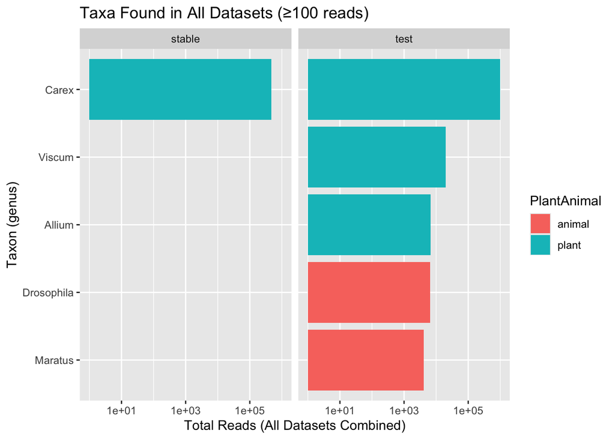

```r
all_labels <- unique(genus$label)
n_total_labels <- length(all_labels)
abundant_taxa <- genus %>%
  filter(nreads >= 100)

ubiquitous_taxa <- abundant_taxa %>%
  group_by(name, PlantAnimal, comparison) %>%
  summarise(
    n_labels = n_distinct(label),
    total_reads = sum(nreads),
    .groups = "drop"
  ) %>%
  filter(n_labels == n_total_labels)

p <- ggplot(ubiquitous_taxa, aes(x = reorder(name, total_reads), y = total_reads, fill = PlantAnimal)) +
  geom_col() +
  coord_flip() +
  labs(
    title = "Taxa Found in All Datasets (≥100 reads)",
    x = "Taxon (genus)",
    y = "Total Reads (All Datasets Combined)"
  ) + facet_wrap(~comparison) + scale_y_continuous(trans="log10")
ggsave("plots/ubiquitous_taxa.pdf" , plot = p, width = 10, height = 7)
print(p)
```

Find damage of these bad taxa

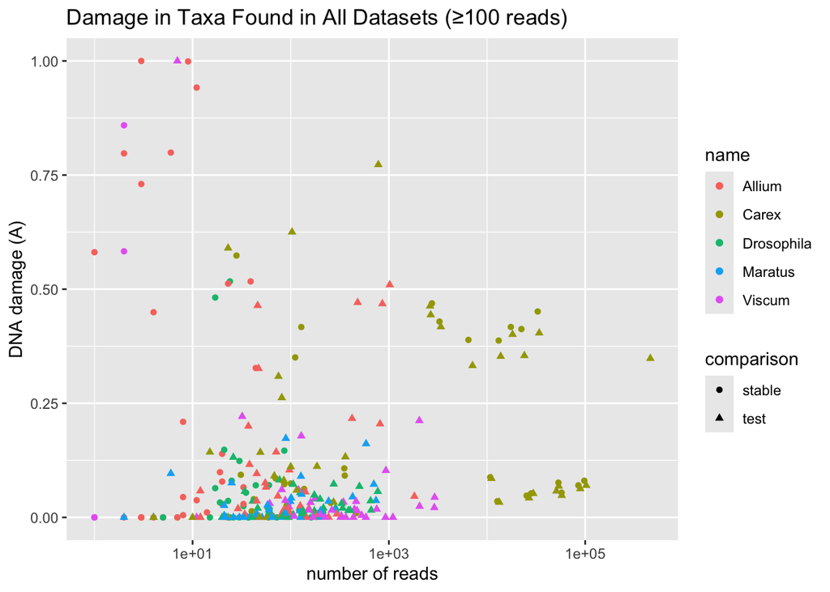

```r
bad <- genus %>% filter(name %in% ubiquitous_taxa$name)

p <- ggplot(bad, aes(x=nreads,y=A,shape=comparison,color=name)) +
  geom_point() + scale_x_continuous(trans="log10") +
   labs(
    title = "Damage in Taxa Found in All Datasets (≥100 reads)",
    x = "number of reads",
    y = "DNA damage (A)"
  )
ggsave("plots/ubiquitous_taxa_dmg.pdf" , plot = p, width = 10, height = 7)
print(p)
```

Which are shared by at least 2?

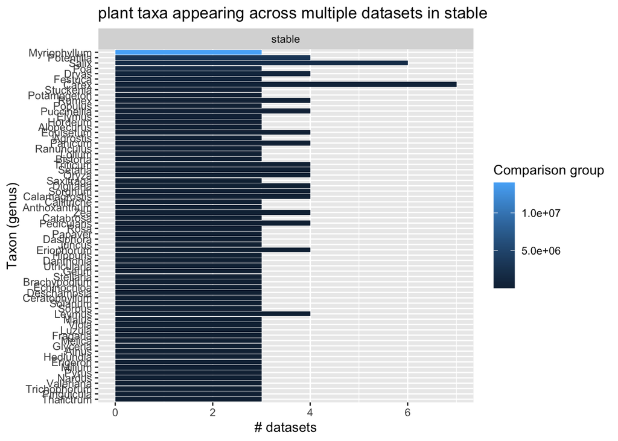

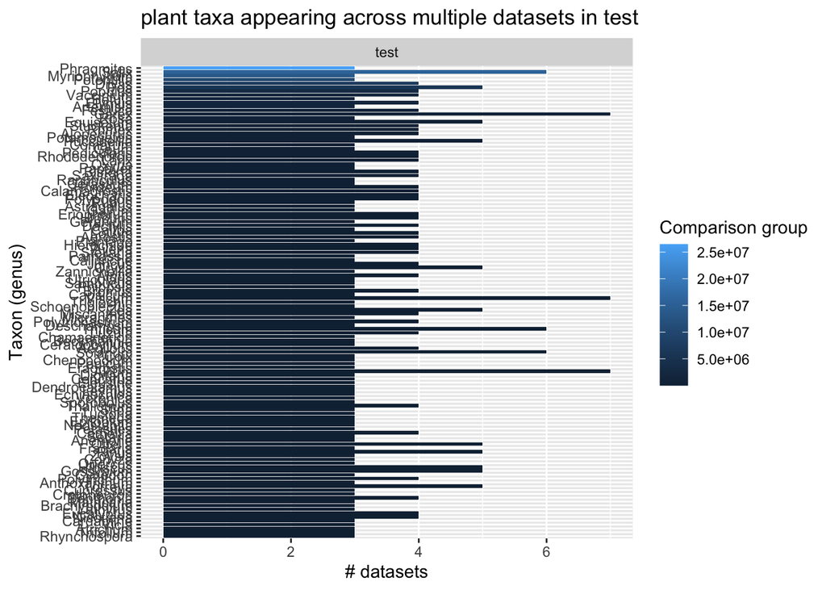

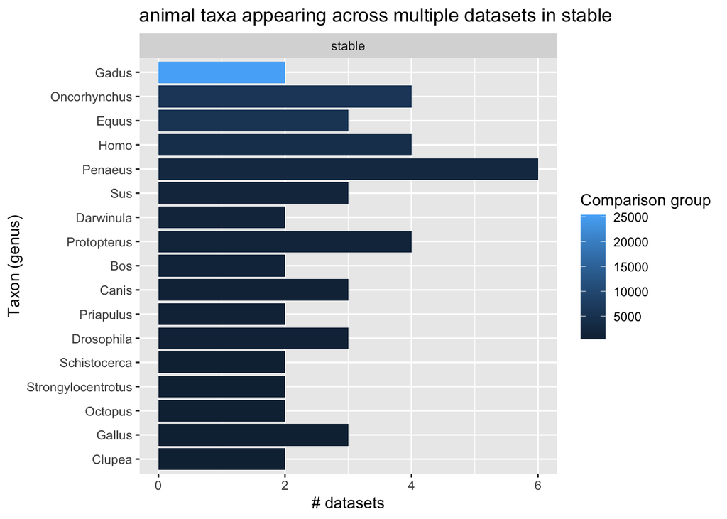

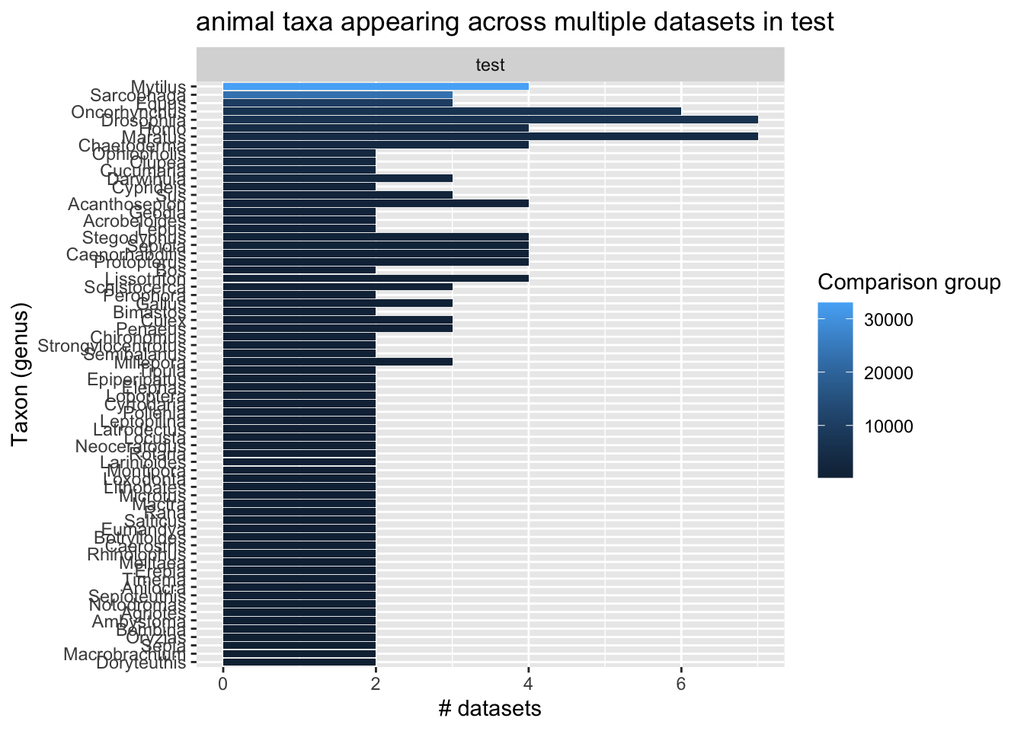

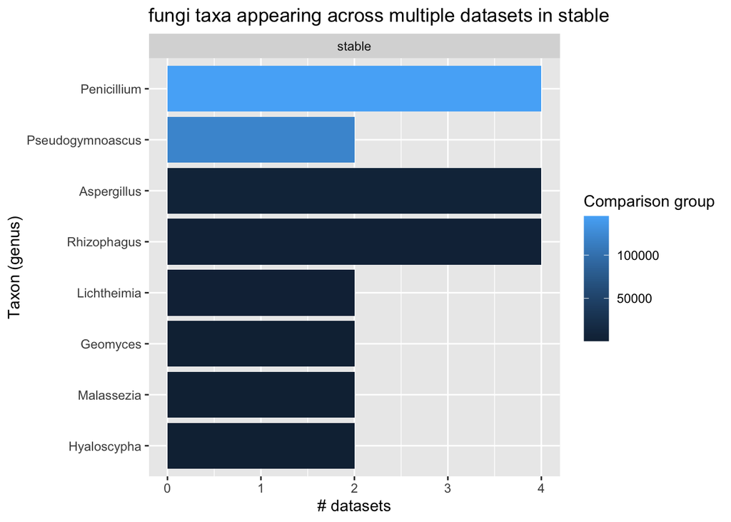

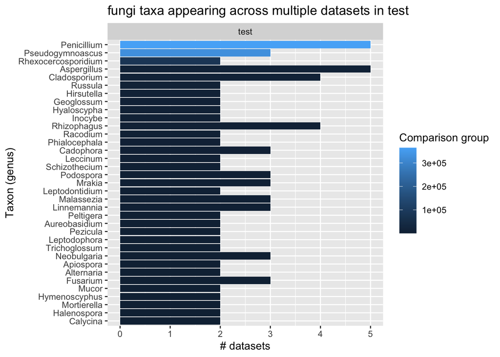

```r
abundant_taxa <- genus %>%
  filter(nreads >= 100)
# count how many groups each taxa is in
taxa_presence <- abundant_taxa %>%
  group_by(name, PlantAnimal, comparison) %>%
  summarise(
    n_labels = n_distinct(label),
    total_reads = sum(nreads),
    .groups = "drop"
  )

# filter for taxa in at least 2
taxa_filtered <- taxa_presence %>%
  filter(n_labels >= 2)

for (pl in unique(taxa_filtered$PlantAnimal)) {
  for (s in c("stable","test")) {


  df_sub <- taxa_filtered %>% filter(PlantAnimal == pl & comparison == s)

  if (pl == "plant"){
    df_sub <- df_sub %>% filter(total_reads >= 500 & n_labels >= 3) # stricter for plants because many
  }
  p <- ggplot(df_sub, aes(x = reorder(name, total_reads), y = n_labels, fill = total_reads)) +
    geom_col(position = position_dodge()) +
    coord_flip() +
    labs(
      title = paste0(pl, " taxa appearing across multiple datasets in ", s),
      x = "Taxon (genus)",
      y = "# datasets",
      fill = "Comparison group"
    ) + facet_wrap(~comparison)

  fname <- paste0("plots/common_taxa_", pl,"_",s, ".pdf")
  ggsave(fname, plot = p, width = 10, height = 7)
  print(p)
  }
}
```